# WISPR calibration

Guide for measuring and formatting WISPR system sensitivity

*DRAFT*

*This page was assembled from a more chaotic but possibly more detailed Google Doc [WISPR Sensitivity Measurement](https://docs.google.com/document/d/1Rx4ZI_vU_zIv3D66HPnFLJdk0iMx67Wh25fIO6qGQ50/edit?tab=t.0#heading=h.p6aqnfpw5pme)*

### Goals:

1. Measure frequency-dependent sensitivity of a Seaglider-type WISPR3 and integrated preamplifier (preamp gain curve)
2. Combine the preamp gain curve with other system calibration info (hydrophone sensitivity, system gain) to produce an overall system response curve that can be used to produce calibrated noise measurements and be uploaded with raw data to NCEI, in a format that is compatibile with noise and soundscape analyses

Ideally this process is conducted before and after each deployment to track any possible changes in preamplifier sensitivity over time as the WISPR3 system sits on the shelf or is out on a mission.

### Equipment

- Laptop
  - Needs to have at least 2 USB-B ports and 1 USB-C port or a hub
  - Install Waveforms software from Digilent ([Download here](https://digilent.com/reference/software/waveforms/waveforms-3/start?srsltid=AfmBOoqQFAVA5bOYY3qVcSi-L1BjduXonW3feLVdlmE9vslEZtLLzPh3))
  - MATLAB with *agate* toolbox
- Digilent Analog Discovery 3
- Bench power supply (for powering WISPR)
- Homemade cables
  - Power cable to power WISPR3. Requires three wires - ground, power, and ‘enable’ that is used by the glider to turn WISPR on and off
  - Two UART (univeral asynchronous receiver transmitter) cables
    - Built from WISPR3 docs section 1.2.3 but skipped wire 6 - PWR out to hydrophone because not needed here. Far right, square is pin 1/ground
    - Both use a USB to TTL/CMOS (purchased from digikey) that reduces the USB voltage to the CMOS (transistor) level that the WISPR3 board can accept. **Set Power Supply swithch to 3.3 v to talk WISPR3**
    - UART0 cable has ground, UART0 transmit, UART0 receive
    - UART1 cable has ground, UART1 transmit, UART1 receive
  - Hydrophone cable to receive the calibration signal. Requires three wires - ground, positive, and negative inputs
  - Digilent BNC connector (purchased) and BNC cables (two - one for positive and one for negative inputs on hydrophone cable)
- 20 dB attenuators

## Set up

[figure not shown]

## Procedure

### Process calibration sweep recordings

Use `agate` to measure the WISPR3 board and preamp sensitivity from the recorded calibration sweep signals. See `workflow_wisprSystemSensitivity.m` in the `agate/example_workflows` folder for an example or follow the below steps.

```matlab
% make sure agate is on the path
addpath(genpath('C:\Users\User.Name\Documents\MATLAB\agate'))
```

To preview or browse through the recordings in your preferred analysis software, convert the recorded `.dat` files to `.flac` or `.wav`. This can be useful to pick which file has a full calibration signal that you will want to select in the measurement step.

```matlab
convertWispr;

% this call with no input arguments will prompt to select raw file location
% and output file location and will default to writing flac. Alternatively,
% specify input arguments to avoid prompts and write to .wav. E.g.,
% convertWispr('inDir', 'E:/wisprFiles', 'outDir', 'E:/wav', 'outExt', '.wav')
```

Review the files and find one that has a nice complete calibration signal.

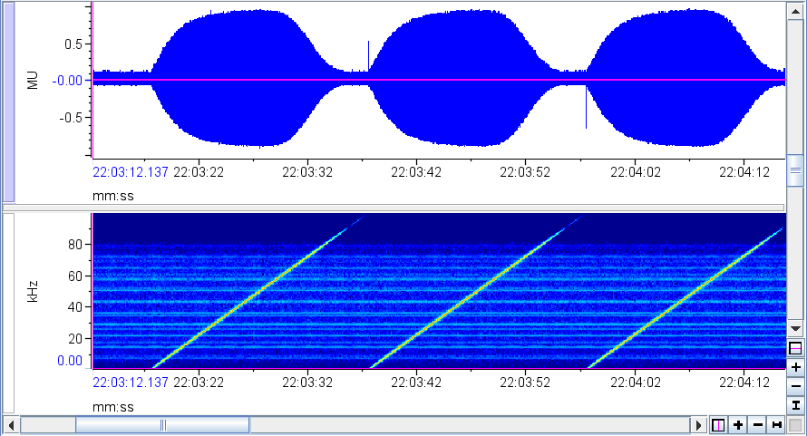

Example showing three 20 second sweeps from 0 to 100 kHz.

Define the input arguments needed for the measurement step.

```matlab
% serial number of the WISPR preamp/adc board - must be a string < 16 chars
% used for filename generation and output file header info
sn = 'WISPR3_no#';

% fullfile path of calibration recording (as raw .dat file)
sweep_file = []; % set to [] to be prompted to select file OR define
% sweep_file = "E:\wispr_calibration\wispr_no2\250514\WISPR_250514_213247.dat";

% define hydrophone sensitivity, not required, used in output file header
hydro_sens = -164.5;

% define the amplitude of sine wave sweep (in volts) and sweep duration
% typically 10 mV and 20 or 60 seconds
amp = 0.010;
dur = 20; % in seconds

% was a 20 dB attenuator used?
attenuator = true;

% path to save output calibration files
path_out = 'C:\Users\User.Name\calibration\wispr\preamps';

% OPTIONAL
% specify an output filename. Default is SN_preamp_gain_YYYY-MM-DD
% where the timestamp is the date of creation. Do not specify an extension.
out_file_name = []; % set to [] to use default
% out_file_name = 'testFile';
```

Run the measurement function.

```matlab
% this function will plot the waveform of the specified calibration sweep
% file, prompt the user to select the start of one complete sweep,
% calculate the spectrum over the duration of one sweep, save the
% frequency-dependent gain curve as a .mat and .txt and the plot as .png

[paFreq, paGain] = measureWisprPreampSensitivity(sn, sweep_file, ...
    hydro_sens, amp, dur, attenuator, path_out, out_file_name);
```

This will plot the waveform of the selected sweep file and prompt the user to select the start of a single sweep. This should be the initial increase in the waveform. A single sweep will be extracted from this point and based on the specified sweep duration.

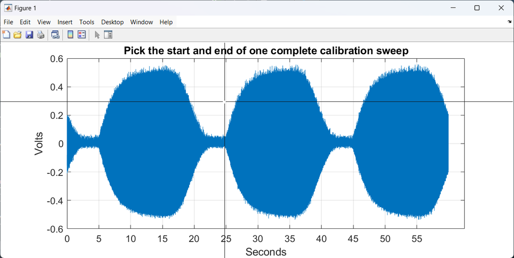

Example showing selection of a single 20 second sweep from the waveform.

[figure not shown]

Back to top